# Topic 1 Exercises

# Discussion questions

2.4.1, 2.4.3, 2.4.6:

2.4.1: a) A flexible approach would be better as it would fit the model better and reduce bias. A large sample size would benefit with a flexible model as opposed to an inflexible one.

2. A flexible approach would be worse as it would overfit the data as the sample size is small.
3. Flexible would be better as there would be a greater degree of freedom and a flexible model would obtain a better fit.
4. A flexible model would be worse as flexibility would just increase the amount of variance.

2. squared bias- decreases monotonically because greater flexibility fits the data better.

Training error - Training error declines monotonically as flexibility increases. This is because as flexibility increases, the data is fit better.

Test error - concave up as greater flexibility means a better fit till a certain point and then it levels off and starts to increase again (overfits the data). The test error is the sum of Bayes error, bias and variance. Thus it can never lie below the dotted line (Bayes error)

Bayes error - The horizontal dashed line indicates the irreducible error which corresponds to the lowest achievable test MSE among all possible methods.

Variance - Increases monotonically because increases in flexibility yields overfitting the data.

2.4.6:

A parametric approach makes an assumption for the functional form or shape of f. It reduces the problem of estimating f down to one of estimating the parameters. Non parametric models do not make an assumption for the functional form or shape of f. It requires a very large number of observations to accurately estimate f.

The advantages of parametric to regression or classification is that not many observations are needed as compared to a non parametric approach and it simplifies it to just estimating the parameters for a model for f.

The disadvantages are that the model chosen for f could be wrong which would inaccurately estimate f or overfit the observations if more flexible models are used.

# Computing Assignment

2.4.8, 2.4.9

2.4.8: a)

```r
##download.file("http://www-bcf.usc.edu/~gareth/ISL/College.csv", destfile="College.csv")
```

```r
auto_file_name = "/home/local/MAC/njain/Math-253-Assignments ssh/College.csv"
```

```r
college = read.csv(auto_file_name,header=T,na.strings ="?")
```

```r
#instead of fix, use view(college) in console
#rownames(college) = college[,1]
#college = college[,-1]
```

```r
#i)
summary(college)
```

```
##                             X       Private        Apps
##  Abilene Christian University:  1   No :212   Min.   :   81
##  Adelphi University          :  1   Yes:565   1st Qu.:  776
##  Adrian College              :  1             Median : 1558
##  Agnes Scott College         :  1             Mean   : 3002
##  Alaska Pacific University   :  1             3rd Qu.: 3624
##  Albertson College           :  1             Max.   :48094
##  (Other)                     :771
##      Accept          Enroll       Top10perc       Top25perc
##  Min.   :   72   Min.   :  35   Min.   : 1.00   Min.   :  9.0
##  1st Qu.:  604   1st Qu.: 242   1st Qu.:15.00   1st Qu.: 41.0
##  Median : 1110   Median : 434   Median :23.00   Median : 54.0
##  Mean   : 2019   Mean   : 780   Mean   :27.56   Mean   : 55.8
##  3rd Qu.: 2424   3rd Qu.: 902   3rd Qu.:35.00   3rd Qu.: 69.0
##  Max.   :26330   Max.   :6392   Max.   :96.00   Max.   :100.0
##
##   F.Undergrad     P.Undergrad         Outstate       Room.Board
##  Min.   :  139   Min.   :    1.0   Min.   : 2340   Min.   :1780
##  1st Qu.:  992   1st Qu.:   95.0   1st Qu.: 7320   1st Qu.:3597
##  Median : 1707   Median :  353.0   Median : 9990   Median :4200
##  Mean   : 3700   Mean   :  855.3   Mean   :10441   Mean   :4358
##  3rd Qu.: 4005   3rd Qu.:  967.0   3rd Qu.:12925   3rd Qu.:5050
##  Max.   :31643   Max.   :21836.0   Max.   :21700   Max.   :8124
##
##      Books           Personal         PhD            Terminal
##  Min.   :  96.0   Min.   : 250   Min.   :  8.00   Min.   : 24.0
##  1st Qu.: 470.0   1st Qu.: 850   1st Qu.: 62.00   1st Qu.: 71.0
##  Median : 500.0   Median :1200   Median : 75.00   Median : 82.0
##  Mean   : 549.4   Mean   :1341   Mean   : 72.66   Mean   : 79.7
##  3rd Qu.: 600.0   3rd Qu.:1700   3rd Qu.: 85.00   3rd Qu.: 92.0
##  Max.   :2340.0   Max.   :6800   Max.   :103.00   Max.   :100.0
##
##    S.F.Ratio      perc.alumni        Expend        Grad.Rate
##  Min.   : 2.50   Min.   : 0.00   Min.   : 3186   Min.   : 10.00
##  1st Qu.:11.50   1st Qu.:13.00   1st Qu.: 6751   1st Qu.: 53.00
##  Median :13.60   Median :21.00   Median : 8377   Median : 65.00
##  Mean   :14.09   Mean   :22.74   Mean   : 9660   Mean   : 65.46
##  3rd Qu.:16.50   3rd Qu.:31.00   3rd Qu.:10830   3rd Qu.: 78.00
##  Max.   :39.80   Max.   :64.00   Max.   :56233   Max.   :118.00
##
```

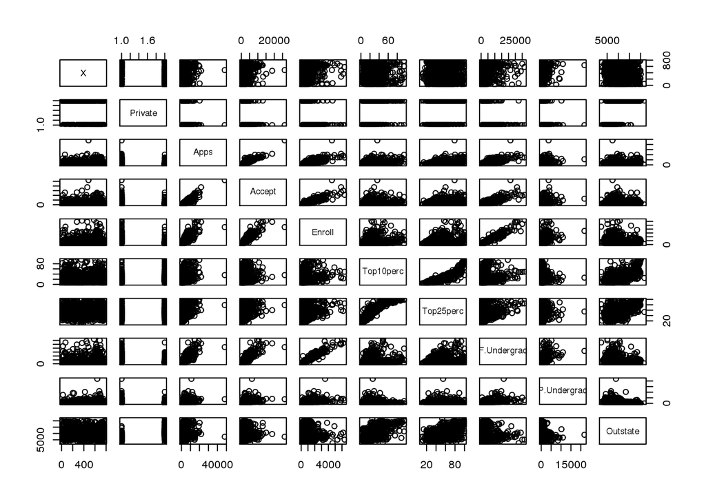

```r
#ii)
pairs(college[,1:10])
```

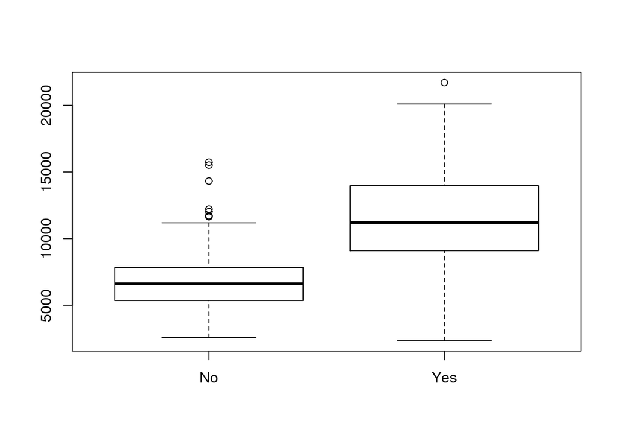

```r
#iii)
plot(college$Private, college$Outstate)
```

```r
#iv)
Elite = rep("No", nrow(college))
Elite[college$Top10perc>50] = "Yes"
Elite= as.factor(Elite)
college = data.frame(college, Elite)
summary(college$Elite)
```

```
##  No Yes
## 699  78
```

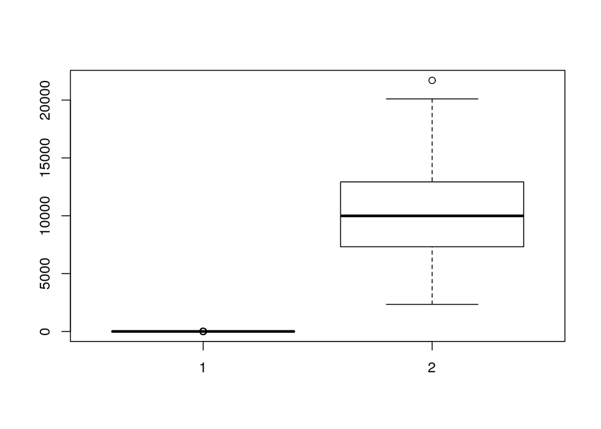

```r
boxplot(college$Elite, college$Outstate)
```

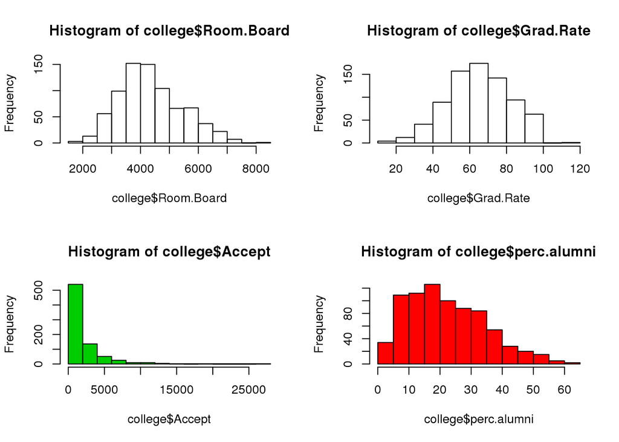

```r
#v)
par(mfrow=c(2,2))
hist(college$Room.Board)
hist(college$Grad.Rate)
hist(college$Accept, col=3)
hist(college$perc.alumni, col=2)
```

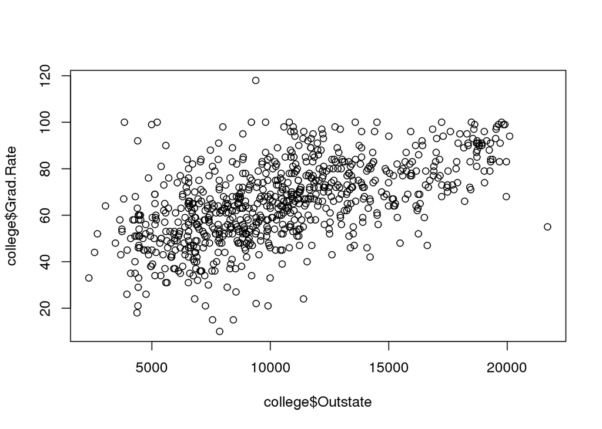

```r
#vi)
par(mfrow=c(1,1))
plot(college$Outstate, college$Grad.Rate)
```

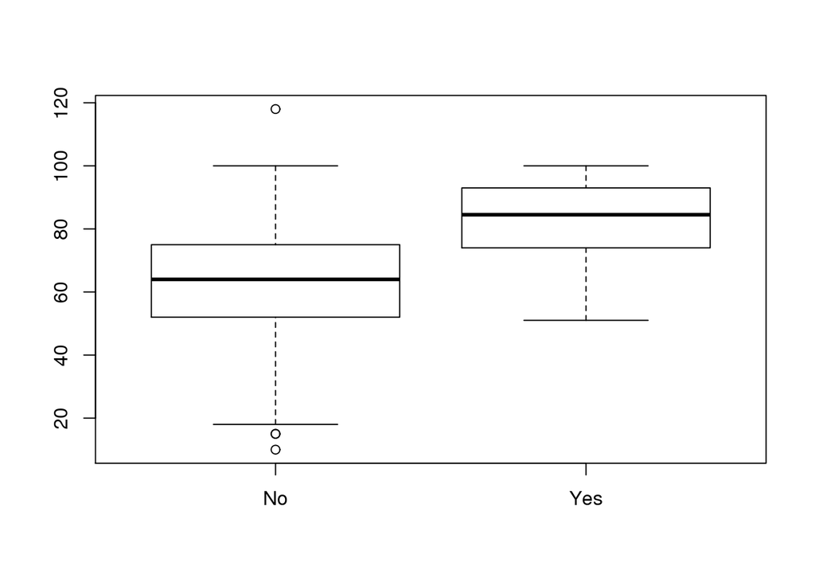

```r
# High tuition correlates to high graduation rate.

plot(college$Elite, college$Grad.Rate)
```

```r
#Colleges with the most students from top 10% perc (Elite schools) have higher graduation rate. Their box plot is also not as spread out as non-elite schools.
```

2.4.9:

```r
auto_file_name1 = "/home/local/MAC/njain/Math-253-Assignments ssh/Auto.csv"
Auto = read.csv(auto_file_name1,header=T,na.strings ="?")
Auto= na.omit(Auto)
dim(Auto)
```

```
## [1] 392   9
```

```r
summary(Auto)
```

```
##       mpg          cylinders      displacement     horsepower
##  Min.   : 9.00   Min.   :3.000   Min.   : 68.0   Min.   : 46.0
##  1st Qu.:17.00   1st Qu.:4.000   1st Qu.:105.0   1st Qu.: 75.0
##  Median :22.75   Median :4.000   Median :151.0   Median : 93.5
##  Mean   :23.45   Mean   :5.472   Mean   :194.4   Mean   :104.5
##  3rd Qu.:29.00   3rd Qu.:8.000   3rd Qu.:275.8   3rd Qu.:126.0
##  Max.   :46.60   Max.   :8.000   Max.   :455.0   Max.   :230.0
##
##      weight      acceleration        year           origin
##  Min.   :1613   Min.   : 8.00   Min.   :70.00   Min.   :1.000
##  1st Qu.:2225   1st Qu.:13.78   1st Qu.:73.00   1st Qu.:1.000
##  Median :2804   Median :15.50   Median :76.00   Median :1.000
##  Mean   :2978   Mean   :15.54   Mean   :75.98   Mean   :1.577
##  3rd Qu.:3615   3rd Qu.:17.02   3rd Qu.:79.00   3rd Qu.:2.000
##  Max.   :5140   Max.   :24.80   Max.   :82.00   Max.   :3.000
##
##                  name
##  amc matador       :  5
##  ford pinto        :  5
##  toyota corolla    :  5
##  amc gremlin       :  4
##  amc hornet        :  4
##  chevrolet chevette:  4
##  (Other)           :365
```

```r
#a)
#Quantitative: mpg, cylinders, displacement, horsepower, weight, acceleration
#Qualitative: year, origin, name

#b)
sapply(Auto[,1:6], range)
```

```
##       mpg cylinders displacement horsepower weight acceleration
## [1,]  9.0         3           68         46   1613          8.0
## [2,] 46.6         8          455        230   5140         24.8
```

```r
#c)
sapply(Auto[,1:6], mean)
```

```
##          mpg    cylinders displacement   horsepower       weight
##    23.445918     5.471939   194.411990   104.469388  2977.584184
## acceleration
##    15.541327
```

```r
sapply(Auto[,1:6], sd)
```

```
##          mpg    cylinders displacement   horsepower       weight
##     7.805007     1.705783   104.644004    38.491160   849.402560
## acceleration
##     2.758864
```

```r
#d)
newAuto = Auto[-(10:85), ]
#dim(newAuto) == dim(Auto) - c(76,0)
#newAuto[9,] == Auto[9,]
#newAuto[10,] == Auto[86,]
sapply(newAuto[,1:6], range)
```

```
##       mpg cylinders displacement horsepower weight acceleration
## [1,] 11.0         3           68         46   1649          8.5
## [2,] 46.6         8          455        230   4997         24.8
```

```r
sapply(newAuto[,1:6], mean)
```

```
##          mpg    cylinders displacement   horsepower       weight
##    24.404430     5.373418   187.240506   100.721519  2935.971519
## acceleration
##    15.726899
```

```r
sapply(newAuto[,1:6], sd)
```

```
##          mpg    cylinders displacement   horsepower       weight
##     7.867283     1.654179    99.678367    35.708853   811.300208
## acceleration
##     2.693721
```

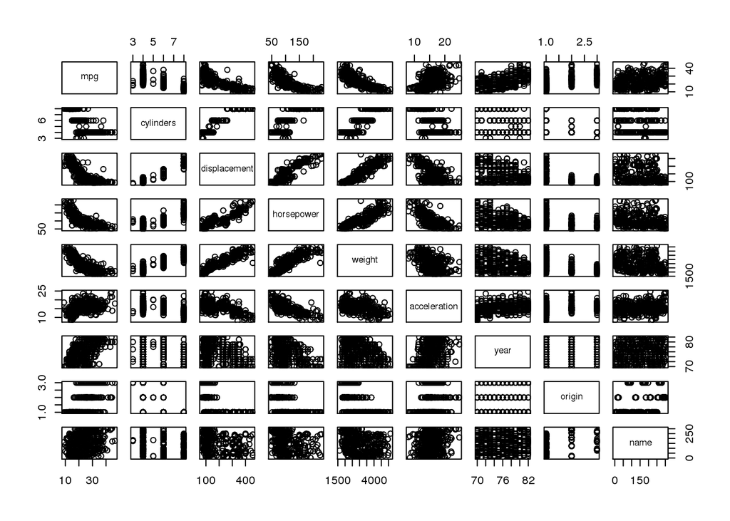

```r
#e)
pairs(Auto)
```

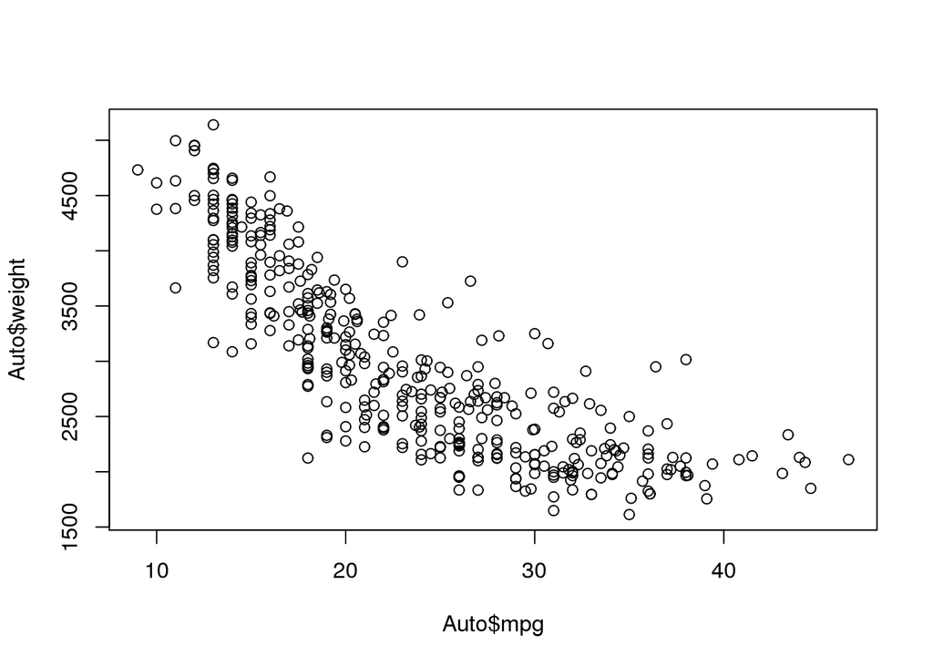

```r
plot(Auto$mpg, Auto$weight)
```